# Consulting Project

**Comments to Critiquers:**

Questions I have:

- What is error 11?
- I am completely off in making my bar charts. I’m not sure where I’m going wrong. Is it because the count is reading the Official.Title column instead of the Department or All.Submitted.Applications columns?
- Why is there so much white space at the bottom of my analysis?
- Not sure how to simplify this data set down with the number of departments and years.

## Background Information

Every year BYU-Idaho faculty positions become vacant for a variety of reasons. Towards the end of summer, positions start being posted. A member of the Faculty Employment Team in Human Resources is then tasked with advertising to help spread the word and fill these positions. The applications have never been measured from year to year. I am part of the team that manages those positions and I would like to see what the trend has been from year to year. Eventually, I would like be able to pull information on individuals and our advertising avenues. For now, I am only able to pull broad information. The hope is to see if there are any noticeable trends within a certain departments, years, or other scenerios to help with advertising and departmental needs. Some questions that I hope I can answer either now in this analysis, or later on during my time of employment with this team, is:

### Questions For Now

1. Are we increasing the number of applicants each year?
2. Are we able to predict the number of applicants a department might receive?
3. Which departments are the hardest and easiest to obtain a hearty applicant pool?
4. How many faculty job postings have we had to fill each year?
5. How many applicants do we receive every year?
6. How many applicants does each department receive (i.e. by year, on average, for the last five years)?
7. Is there a connection between the number of submitted and incomplete applications?
8. Do certain departments keep receiving reoccuring multiple job opening positions?

### Questions For Later

1. Are we increasing the number of applicants each year?
2. Are we able to predict the number of applicants a department might receive?
3. Which advertising avenues bring in our applicants?
4. Which departments are the hardest and easiest to obtain a hearty applicant pool?
5. How many faculty job postings have we had to fill each year?
6. How many applicants do we receive every year?
7. How many applicants do each department receive?
8. Is there a connection between the number of submitted and incomplete applications?
9. Is there a correlation between these variables:
1. The amount of money we spend on advertising
2. The type of advertising
3. The number of applicants
4. The number of incomplete applicants
5. Residence of applicant
6. The job market or company an applicant comes from
10. How did we find the correct candidate?
11. How many times did we fail to fill a posting? Why? When?
12. How many applicants receive an Interest Card email?
13. Did receiving an Interest Card email impact if a candidate started or submitted an application?
14. When do we receive the fewest and highest number of applications in a job posting?
15. How long does it take for an application to be submitted?
16. Are applications normally submitted on the same day or spread out over time?
17. At what length of time does an application become incomplete?
18. Where on the application process do applicants commonly stop filling it out?
19. Do letters of reference help an applicant receive a job?
20. What is the ratio of male/female applicants?
21. Are we hiring more Master or PhD degree level applicants?
22. Do certain departments keep receiving reoccuring multiple job opening positions?
23. Which departments are growing the most based upon a job opening?

## Analysis

```r
# Formatting the data I would like to work with: Faculty Positions.

#str_detect(Posting_Information$Official.Title, "Full-time Faculty|Anticipated")

Post_Info <- filter(Posting_Information, str_detect(Posting_Information$Official.Title, "Full-time Faculty|Anticipated"))

Multiple_Openings <- filter(Post_Info, str_detect(Post_Info$Official.Title, "Position|position|Opening|opening"))

#View(Post_Info) #This is for all positions
#View(Multiple_Openings) #This is for positions with multiple openings

Post_Info$Closing.Date <- as.character(Post_Info$Closing.Date)

Clean_Post_Info <- Post_Info %>%
  mutate(Year = str_replace_all(Post_Info$Closing.Date, "\\.+", "") ) %>%
  mutate(Year = str_extract_all(Post_Info$Closing.Date, "[:digit:]{4,7}") )

Clean_Post_Info$Year <- as.numeric(Clean_Post_Info$Year)
Clean_Post_Info$ByYear <- as.factor(Clean_Post_Info$Year)

#View(Clean_Post_Info)
```

### Basic Overview

**Multiple Linear Regression:**

$$\underbrace{\hat{Y}_i}_\text{Submitted Applications} = \overbrace{b_0}^\text{y-int} + \overbrace{b_1}^\text{slope} \underbrace{X_{1i}}_\text{Incomplete Applications} + b_2 \overbrace{X_{2i}}^\text{Is a Department} + b_3 \underbrace{X_{1i}X_{2i}}_\text{Interaction of Applic. and Dept.}$$

- The number of Incomplete Applications has no impact on the number of submitted applications
- A quick glance through the our test shows a few departments having an impact on the number of applications we receive.

$$\alpha = 0.05$$

English ($p$-value = 0.03603)  
Religious Education (5.753e-05)

$$\alpha = 0.1$$

Art ($p$-value = 0.09502)  
Languages & International Studies (0.05755)  
Music (0.05138)  
Teacher Education (0.08351)

- There is no significance between any of the interactions with Incomplete Applications and Departments.
- Error Terms may not be independent of one another.

**ANOVA**

- We are looking at how the Year and Department impact the number of applications.
- Both the type of year ($p$-value = 0.0007707) and department (1.172e-18) have had meaningful differences in the number of applications received.
- The error terms are not normally distributed. Data and test cannot be fully trusted.
- Looks like 2008 had some huge impact on application. Not sure why.
- Looks like Foundations & Interdisciplinary Studies may be an influencer with 74.5 submitted applications.

```r
Clean_Post_Info %>%
  group_by(Year) %>%
  summarise(Min = min(All.Submitted.Applications),
            Median = median(All.Submitted.Applications),
            Mean = mean(All.Submitted.Applications),
            Max = max(All.Submitted.Applications),
            SD = sd(All.Submitted.Applications),
            ) %>%
pander(caption="Summary of Yearly Submissions")
```

Summary of Yearly Submissions

| Year | Min | Median | Mean | Max | SD |
| --- | --- | --- | --- | --- | --- |
| 2008 | 63 | 63 | 63 | 63 | NA |
| 2009 | 4 | 9 | 12.43 | 39 | 12.33 |
| 2010 | 2 | 10 | 13.41 | 41 | 10.19 |
| 2011 | 2 | 13.5 | 16.43 | 61 | 14.27 |
| 2012 | 2 | 13 | 16.86 | 70 | 13.68 |
| 2013 | 1 | 10 | 13.03 | 51 | 9.694 |
| 2014 | 3 | 10.5 | 13.12 | 50 | 10.5 |
| 2015 | 1 | 9 | 10.54 | 33 | 8.038 |
| 2016 | 5 | 12 | 17 | 64 | 13.26 |
| 2017 | 1 | 11 | 17.96 | 70 | 17.52 |
| 2018 | 1 | 18 | 24.15 | 131 | 24.12 |
| 2019 | 1 | 17 | 21.97 | 66 | 16.04 |

### Multiple Linear

```r
#mPlot(Clean_Post_Info)


Posting.lm <- lm(All.Submitted.Applications ~ Incomplete.Applications + Department + Incomplete.Applications:Department, data = Clean_Post_Info)
pander(summary(Posting.lm), split.table=Inf)
```

|  | Estimate | Std. Error | t value | Pr(>\|t\|) |
| --- | --- | --- | --- | --- |
| **(Intercept)** | 12.9 | 1.933 | 6.675 | 1.521e-10 |
| **Incomplete.Applications** | 2.952 | 2.58 | 1.144 | 0.2537 |
| **DepartmentAcademic Support Centers** | -1.959 | 11.47 | -0.1708 | 0.8645 |
| **DepartmentAccounting** | -4.325 | 8.706 | -0.4968 | 0.6197 |
| **DepartmentAnimal & Food Sciences** | -7.234 | 5.936 | -1.219 | 0.2241 |
| **DepartmentApplied Plant Science** | -4.734 | 4.414 | -1.072 | 0.2846 |
| **DepartmentArt** | -8.061 | 4.811 | -1.676 | 0.09502 |
| **DepartmentAutomotive Technology** | -9 | 8.36 | -1.077 | 0.2827 |
| **DepartmentBiology** | 6.86 | 4.366 | 1.571 | 0.1174 |
| **DepartmentChemistry** | -2.567 | 4.608 | -0.5571 | 0.578 |
| **DepartmentCommunication** | -0.4877 | 4.112 | -0.1186 | 0.9057 |
| **DepartmentComputer Information Technology** | -3.772 | 5.794 | -0.651 | 0.5156 |
| **DepartmentComputer Science & Elec Engineering** | -5.616 | 4.544 | -1.236 | 0.2176 |
| **DepartmentConstruct Mgmt, Arch, Int Des** | -7.852 | 9.936 | -0.7903 | 0.4301 |
| **DepartmentDance** | -7.9 | 7.14 | -1.106 | 0.2696 |
| **DepartmentDesign and Construction Management** | 0.9211 | 7.373 | 0.1249 | 0.9007 |
| **DepartmentEconomics** | -3.329 | 4.152 | -0.8019 | 0.4234 |
| **DepartmentEnglish** | 9.468 | 4.492 | 2.108 | 0.03603 |
| **DepartmentFinance** | 12.77 | 13.5 | 0.9457 | 0.3452 |
| **DepartmentFoundations & Interdisciplinary Studies** | -20.73 | 12.3 | -1.685 | 0.09318 |
| **DepartmentGeology** | -6.4 | 7.14 | -0.8964 | 0.3709 |
| **DepartmentHealth Services** | -1.525 | 17.88 | -0.08531 | 0.9321 |
| **DepartmentHistory/Geography/Poli Science** | 1.161 | 5.685 | 0.2042 | 0.8384 |
| **DepartmentHome & Family** | -4.218 | 4.398 | -0.9592 | 0.3384 |
| **DepartmentHuman Performance & Recreation** | 0.09966 | 6.037 | 0.01651 | 0.9868 |
| **DepartmentHumanities & Philosophy** | 4.148 | 9.936 | 0.4174 | 0.6767 |
| **DepartmentInterdisciplinary Studies** | -5.852 | 9.936 | -0.589 | 0.5564 |
| **DepartmentLanguages & International Studies** | -9.255 | 4.851 | -1.908 | 0.05755 |
| **DepartmentManagement** | 4.87 | 3.836 | 1.27 | 0.2054 |
| **DepartmentMarketing** | 1.516 | 10.55 | 0.1437 | 0.8859 |
| **DepartmentMathematics** | -4.427 | 4.139 | -1.07 | 0.2858 |
| **DepartmentMechanical and Civil Engineering** | -5.274 | 4.102 | -1.286 | 0.1997 |
| **DepartmentMusic** | -6.872 | 3.511 | -1.957 | 0.05138 |
| **DepartmentNursing** | -1.334 | 7.569 | -0.1762 | 0.8603 |
| **DepartmentPhysics** | 0.736 | 9.003 | 0.08175 | 0.9349 |
| **DepartmentPsychology** | -3.828 | 4.505 | -0.8497 | 0.3963 |
| **DepartmentReligious Education** | 23.67 | 5.785 | 4.091 | 5.753e-05 |
| **DepartmentSociology and Social Work** | -7.877 | 7.449 | -1.057 | 0.2913 |
| **DepartmentTeacher Education** | 6.968 | 4.01 | 1.737 | 0.08351 |
| **DepartmentTheatre & Dance** | -8.9 | 7.14 | -1.246 | 0.2137 |
| **Incomplete.Applications:DepartmentAcademic Support Centers** | -0.4029 | 3.751 | -0.1074 | 0.9146 |
| **Incomplete.Applications:DepartmentAccounting** | -0.07689 | 3.545 | -0.02169 | 0.9827 |
| **Incomplete.Applications:DepartmentAnimal & Food Sciences** | -2.819 | 7.554 | -0.3731 | 0.7094 |
| **Incomplete.Applications:DepartmentApplied Plant Science** | -2.535 | 5.85 | -0.4334 | 0.6651 |
| **Incomplete.Applications:DepartmentArt** | -0.6483 | 2.739 | -0.2367 | 0.8131 |
| **Incomplete.Applications:DepartmentAutomotive Technology** | -0.05189 | 5.055 | -0.01026 | 0.9918 |
| **Incomplete.Applications:DepartmentBiology** | -2.647 | 2.827 | -0.9365 | 0.3499 |
| **Incomplete.Applications:DepartmentChemistry** | -0.9519 | 4.734 | -0.2011 | 0.8408 |
| **Incomplete.Applications:DepartmentCommunication** | -1.82 | 2.808 | -0.648 | 0.5175 |
| **Incomplete.Applications:DepartmentComputer Information Technology** | -2.884 | 2.967 | -0.9718 | 0.3321 |
| **Incomplete.Applications:DepartmentComputer Science & Elec Engineering** | -1.754 | 3.094 | -0.567 | 0.5712 |
| **Incomplete.Applications:DepartmentDesign and Construction Management** | -2.238 | 3.662 | -0.6111 | 0.5417 |
| **Incomplete.Applications:DepartmentEconomics** | -1.809 | 4.319 | -0.4188 | 0.6757 |
| **Incomplete.Applications:DepartmentEnglish** | -1.3 | 2.656 | -0.4895 | 0.6249 |
| **Incomplete.Applications:DepartmentFinance** | -2.785 | 3.451 | -0.8071 | 0.4203 |
| **Incomplete.Applications:DepartmentFoundations & Interdisciplinary Studies** | 0.2767 | 2.61 | 0.106 | 0.9157 |
| **Incomplete.Applications:DepartmentGeology** | 0.04811 | 10.06 | 0.004783 | 0.9962 |
| **Incomplete.Applications:DepartmentHealth Services** | -2.077 | 3.939 | -0.5272 | 0.5985 |
| **Incomplete.Applications:DepartmentHistory/Geography/Poli Science** | -0.7122 | 2.867 | -0.2484 | 0.804 |
| **Incomplete.Applications:DepartmentHome & Family** | -0.9303 | 2.874 | -0.3237 | 0.7465 |
| **Incomplete.Applications:DepartmentHuman Performance & Recreation** | -2.952 | 3.968 | -0.7439 | 0.4576 |
| **Incomplete.Applications:DepartmentLanguages & International Studies** | -1.186 | 2.834 | -0.4187 | 0.6758 |
| **Incomplete.Applications:DepartmentManagement** | 0.1564 | 2.637 | 0.05933 | 0.9527 |
| **Incomplete.Applications:DepartmentMarketing** | -3.119 | 3.451 | -0.9037 | 0.367 |
| **Incomplete.Applications:DepartmentMathematics** | -1.395 | 2.809 | -0.4965 | 0.62 |
| **Incomplete.Applications:DepartmentMechanical and Civil Engineering** | -0.8784 | 3.03 | -0.2899 | 0.7721 |
| **Incomplete.Applications:DepartmentMusic** | -0.4621 | 2.672 | -0.1729 | 0.8628 |
| **Incomplete.Applications:DepartmentNursing** | -2.652 | 4.013 | -0.6608 | 0.5094 |
| **Incomplete.Applications:DepartmentPhysics** | -3.861 | 6.405 | -0.6028 | 0.5472 |
| **Incomplete.Applications:DepartmentPsychology** | -1.939 | 2.699 | -0.7186 | 0.473 |
| **Incomplete.Applications:DepartmentReligious Education** | -2.215 | 2.616 | -0.8466 | 0.398 |
| **Incomplete.Applications:DepartmentSociology and Social Work** | -0.2614 | 3.34 | -0.07826 | 0.9377 |
| **Incomplete.Applications:DepartmentTeacher Education** | -0.7868 | 2.603 | -0.3023 | 0.7627 |

Fitting linear model: All.Submitted.Applications ~ Incomplete.Applications + Department + Incomplete.Applications:Department

| Observations | Residual Std. Error | $R^2$ | Adjusted $R^2$ |
| --- | --- | --- | --- |
| 329 | 9.721 | 0.6671 | 0.5735 |

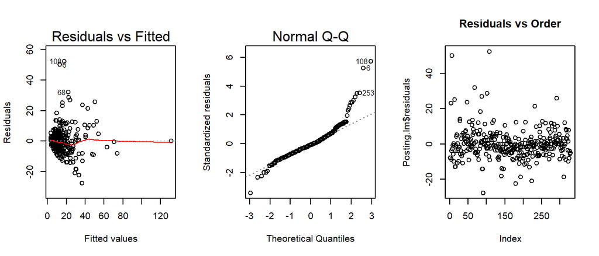

```r
par(mfrow = c(1,3))
plot(Posting.lm,
     which = 1:2)
plot(Posting.lm$residuals,
     main = "Residuals vs Order")
```

### Bar Plots

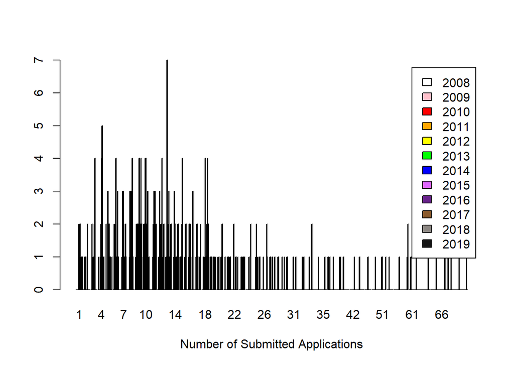

```r
barplot(table(Clean_Post_Info$ByYear, Clean_Post_Info$All.Submitted.Applications),
        beside=TRUE,
        col=c("white", "pink", "red", "orange", "yellow", "green", "blue", "mediumorchid1", "darkorchid4", "tan4", "seashell4", "gray8"),
        legend.text=TRUE,
        xlab="Number of Submitted Applications")
```

### ANOVA

```r
Clean_Post_Info %>%
  group_by(Year) %>%
  summarise(Min = min(All.Submitted.Applications),
            Median = median(All.Submitted.Applications),
            Mean = mean(All.Submitted.Applications),
            Max = max(All.Submitted.Applications),
            SD = sd(All.Submitted.Applications),
            ) %>%
pander(caption="Summary of Yearly Submissions")
```

Summary of Yearly Submissions

| Year | Min | Median | Mean | Max | SD |
| --- | --- | --- | --- | --- | --- |
| 2008 | 63 | 63 | 63 | 63 | NA |
| 2009 | 4 | 9 | 12.43 | 39 | 12.33 |
| 2010 | 2 | 10 | 13.41 | 41 | 10.19 |
| 2011 | 2 | 13.5 | 16.43 | 61 | 14.27 |
| 2012 | 2 | 13 | 16.86 | 70 | 13.68 |
| 2013 | 1 | 10 | 13.03 | 51 | 9.694 |
| 2014 | 3 | 10.5 | 13.12 | 50 | 10.5 |
| 2015 | 1 | 9 | 10.54 | 33 | 8.038 |
| 2016 | 5 | 12 | 17 | 64 | 13.26 |
| 2017 | 1 | 11 | 17.96 | 70 | 17.52 |
| 2018 | 1 | 18 | 24.15 | 131 | 24.12 |
| 2019 | 1 | 17 | 21.97 | 66 | 16.04 |

```r
Clean_Post_Info %>%
  group_by(Department) %>%
  summarise(Min = min(All.Submitted.Applications),
            Median = median(All.Submitted.Applications),
            Mean = mean(All.Submitted.Applications),
            Max = max(All.Submitted.Applications),
            SD = sd(All.Submitted.Applications),
            ) %>%
pander(caption="Summary of Submissions For a Department")
```

Summary of Submissions For a Department

| Department | Min | Median | Mean | Max | SD |
| --- | --- | --- | --- | --- | --- |
| Academic Office | 2 | 10 | 14.27 | 63 | 11.77 |
| Academic Support Centers | 15 | 17.5 | 20.5 | 32 | 8.021 |
| Accounting | 8 | 18 | 17.2 | 26 | 6.419 |
| Animal & Food Sciences | 3 | 5.5 | 5.75 | 9 | 2.659 |
| Applied Plant Science | 4 | 7 | 8.286 | 16 | 3.817 |
| Art | 4 | 8.5 | 11.75 | 33 | 9.939 |
| Automotive Technology | 2 | 9.5 | 8.25 | 12 | 4.349 |
| Biology | 6 | 19.5 | 20.4 | 33 | 8.329 |
| Chemistry | 4 | 11 | 11.67 | 19 | 4.637 |
| Communication | 3 | 13.5 | 15 | 31 | 7.514 |
| Computer Information Technology | 4 | 9 | 9.333 | 17 | 3.606 |
| Computer Science & Elec Engineering | 1 | 10 | 9.2 | 18 | 5.391 |
| Construct Mgmt, Arch, Int Des | 8 | 8 | 8 | 8 | NA |
| Dance | 3 | 5 | 5 | 7 | 2.828 |
| Design and Construction Management | 9 | 15 | 15.25 | 22 | 7.228 |
| Economics | 1 | 9.5 | 10 | 23 | 7.071 |
| English | 8 | 24 | 29.73 | 65 | 19.15 |
| Finance | 26 | 26.5 | 26.5 | 27 | 0.7071 |
| Foundations & Interdisciplinary Studies | 18 | 74.5 | 74.5 | 131 | 79.9 |
| Geology | 3 | 7.5 | 8 | 14 | 4.967 |
| Health Services | 14 | 14 | 16.33 | 21 | 4.041 |
| History/Geography/Poli Science | 10 | 20 | 21.9 | 42 | 9.539 |
| Home & Family | 4 | 10 | 12.91 | 29 | 8.443 |
| Human Performance & Recreation | 5 | 13 | 13 | 25 | 6.766 |
| Humanities & Philosophy | 20 | 20 | 20 | 20 | NA |
| Interdisciplinary Studies | 10 | 10 | 10 | 10 | NA |
| Languages & International Studies | 1 | 5 | 7.429 | 25 | 8.182 |
| Management | 7 | 23 | 31.12 | 70 | 22.45 |
| Marketing | 12 | 13.5 | 13.75 | 16 | 1.708 |
| Mathematics | 1 | 12 | 12.6 | 26 | 6.443 |
| Mechanical and Civil Engineering | 4 | 8.5 | 11.12 | 28 | 7.745 |
| Music | 1 | 11 | 12.84 | 35 | 9.075 |
| Nursing | 10 | 11.5 | 12.17 | 15 | 2.317 |
| Physics | 8 | 12.5 | 12.5 | 17 | 4.655 |
| Psychology | 2 | 12 | 12.22 | 25 | 7.259 |
| Religious Education | 9 | 43.5 | 43.75 | 61 | 16.48 |
| Sociology and Social Work | 3 | 12 | 11.75 | 20 | 8.057 |
| Teacher Education | 10 | 27.5 | 34.71 | 76 | 22.49 |
| Theatre & Dance | 1 | 4 | 4 | 7 | 4.243 |

```r
# Perform the ANOVA
Posting.myaov <- aov(All.Submitted.Applications ~ Year+Department+Year+Department, data=Clean_Post_Info)

# View the ANOVA Results
pander(summary(Posting.myaov), caption = "Two-Way ANOVA Test Results")
```

Two-Way ANOVA Test Results

|  | Df | Sum Sq | Mean Sq | F value | Pr(>F) |
| --- | --- | --- | --- | --- | --- |
| **Year** | 1 | 1628 | 1628 | 11.56 | 0.0007707 |
| **Department** | 38 | 30316 | 797.8 | 5.661 | 1.172e-18 |
| **Residuals** | 289 | 40728 | 140.9 | NA | NA |

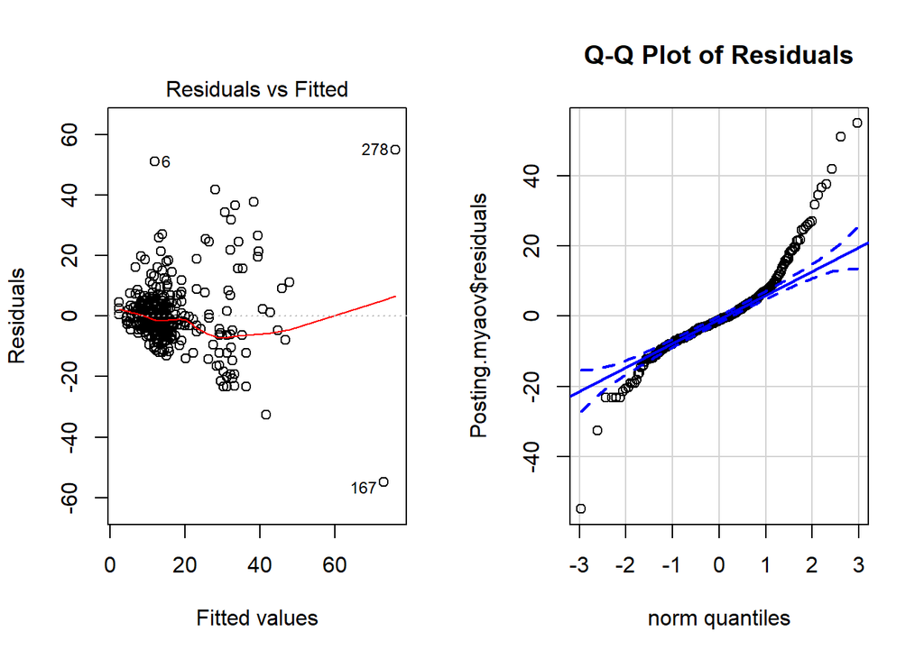

```r
# Check ANOVA Assumptions
par(mfrow = c(1,2))
plot(Posting.myaov,
     which = 1)
qqPlot(Posting.myaov$residuals,
       main = "Q-Q Plot of Residuals",
       id = FALSE)
```

### Show Data

The data comes from BYU-Idaho Human Resources’s account with PeopleAdmin. The data is pulled on our job postings from 1 January 2008 to 30 November 2019.

#### Modified and Used for Analysis

```r
datatable(Post_Info)
```

|  | Official.Title | Posting.Number | Department | Active.Applications | Workflow.State | Last.Status.Update | All.Submitted.Applications | Incomplete.Applications | Pay.Rate | FTE | Accept.References. | Created.Date | Closing.Date | Anticipated.Start.Date |
| --- | --- | --- | --- | --- | --- | --- | --- | --- | --- | --- | --- | --- | --- | --- |
| 1 | Full-time Faculty - Nursing | 600050 | Academic Office | 0 | Filled | May 21, 2009 at 02:57 PM | 5 | 0 | Dependent on education and experience. |  |  | January 27, 2014 at 06:16 PM | 16.01.2009 | 2009-08-24 |
| 2 | Full-time Faculty - Music (Voice) | 600052 | Academic Office | 0 | Filled | May 21, 2009 at 03:00 PM | 5 | 0 | Dependent on education and experience. |  |  | January 27, 2014 at 06:16 PM | 16.01.2009 | 2009-08-24 |
| 3 | Full-time Faculty - Academic Learning | 600058 | Academic Office | 0 | Filled | June 11, 2009 at 01:24 PM | 39 | 1 | Dependent on education and experience. |  |  | January 27, 2014 at 06:16 PM | 16.01.2009 | 2009-08-24 |
| 4 | Full-time Faculty - Computer Science &amp; Engineering | 600060 | Academic Office | 0 | Filled | September 22, 2009 at 02:36 PM | 9 | 0 | Dependent on Education and Experience |  |  | January 27, 2014 at 06:16 PM | 16.01.2009 | 2009-08-24 |
| 5 | Full-time Faculty - Chemistry | 600067 | Academic Office | 0 | Filled | May 21, 2009 at 03:09 PM | 4 | 0 | Dependent on Education and Experience |  |  | January 27, 2014 at 06:16 PM | 16.01.2009 | 2009-08-24 |
| 6 | Full-time Faculty - Religious Education | 600066 | Academic Office | 0 | Filled | May 15, 2009 at 09:41 AM | 63 | 0 | Dependent on Education and Experience |  |  | January 27, 2014 at 06:16 PM | 15.12.2008 | 2009-07-01 |
| 7 | Full-time Faculty - Mathematics (Applied) | 600062 | Academic Office | 0 | Filled | September 22, 2009 at 02:32 PM | 10 | 0 | Dependent on Education and Experience |  |  | January 27, 2014 at 06:16 PM | 16.01.2009 | 2009-08-24 |
| 8 | Full-time Faculty - Theatre | 600094 | Academic Office | 0 | Filled | June 11, 2009 at 01:11 PM | 15 | 1 | Dependent on Education and Experience |  |  | January 27, 2014 at 06:17 PM | 01.04.2009 | 2009-08-24 |
| 9 | Full-time Faculty - Cognitive Psychology | 600198 | Academic Office | 0 | Filled | October 28, 2010 at 03:57 PM | 10 | 1 | Dependent on education and experience. |  |  | January 27, 2014 at 06:17 PM | 31.01.2010 | 2010-08-23 |
| 10 | Full-time Faculty - Horticulture | 600199 | Academic Office | 0 | Filled | October 28, 2010 at 03:37 PM | 13 | 0 | Dependent on education and experience. |  |  | January 27, 2014 at 06:17 PM | 15.03.2010 | 2010-08-23 |

[output cut: 319 more lines]

#### Original Data

```r
datatable(Posting_Information)
```

|  | Official.Title | Posting.Number | Department | Active.Applications | Workflow.State | Last.Status.Update | All.Submitted.Applications | Incomplete.Applications | Pay.Rate | FTE | Accept.References. | Created.Date | Closing.Date | Anticipated.Start.Date |
| --- | --- | --- | --- | --- | --- | --- | --- | --- | --- | --- | --- | --- | --- | --- |
| 1 | Architectural Drafting Specialist I | 600004 | Facilities Management | 0 | Filled | June 03, 2008 at 10:39 AM | 8 | 0 | Payscale starts at $38,271/yr | 1 |  | January 27, 2014 at 06:15 PM | 29.04.2008 | 2008-05-16 |
| 2 | University Store Merchandise Supervisor | 600005 | University Store | 0 | Filled | June 03, 2008 at 10:35 AM | 25 | 1 | Pay scale begins at $45,125/yr | 1 |  | January 27, 2014 at 06:15 PM | 01.05.2008 | 2008-06-01 |
| 3 | Chemistry Laboratory Supervisor | 600003 | Chemistry | 0 | Filled | June 03, 2008 at 10:36 AM | 6 | 0 | Pay scale starts at $42,715/yr | 1 |  | January 27, 2014 at 06:15 PM | 29.04.2008 | 2008-08-01 |
| 4 | Network Engineer | 600007 | Infrastructure | 0 | Filled | June 25, 2008 at 10:53 AM | 11 | 0 | Payscale starts at $42,715/yr | 1 |  | January 27, 2014 at 06:15 PM | 12.05.2008 | 2008-06-01 |
| 5 | Lead Hart Building Monitor | 600009 | Student Activities | 0 | Filled | June 03, 2008 at 10:35 AM | 10 | 0 | Pay scale starts at $12.44/hr | 1 |  | January 27, 2014 at 06:15 PM | 07.05.2008 | 2008-05-16 |
| 6 | Sprinkler Mechanic | 600008 | Grounds | 0 | Filled | June 03, 2008 at 10:35 AM | 6 | 0 | Pay scale starts at $28,350/yr; experience considered for offer | 1 |  | January 27, 2014 at 06:15 PM | 07.05.2008 | 2008-05-16 |
| 7 | Office Assistant I | 600010 | Online Instruction | 0 | Filled | June 03, 2008 at 10:39 AM | 0 | 0 | Pay scale begins at $25,870/yr | 1 |  | January 27, 2014 at 06:15 PM | 12.05.2008 | 2008-06-02 |
| 8 | Custodian | 600011 | Custodial Services | 0 | Filled | June 25, 2008 at 10:51 AM | 6 | 0 | Pay scale begins at $23,600/yr | 1 |  | January 27, 2014 at 06:15 PM | 08.05.2008 | 2008-05-16 |
| 9 | Office Assistant I | 600012 | Online Instruction | 0 | Filled | June 03, 2008 at 10:34 AM | 37 | 2 | Pay scale begins at $25,870/yr | 1 |  | January 27, 2014 at 06:15 PM | 12.05.2008 | 2008-06-02 |
| 10 | Learn to Swim Program Director | 600013 | Continuing Education | 0 | Filled | June 03, 2008 at 10:34 AM | 4 | 0 | $1,500 salary for swim season |  |  | January 27, 2014 at 06:16 PM | 16.05.2008 | 2008-05-28 |

[output cut: 1458 more lines]